# The Bread Basket

#### 4.3.1 Weekend Morning

```r
bread_weekend_morning_df <- bread_weekend_df %>%
  filter(period_day=="morning")

str(bread_weekend_morning_df)
```

```
## tibble [3,230 x 6] (S3: tbl_df/tbl/data.frame)
##  $ Transaction    : num [1:3230] 1 2 2 3 3 3 4 5 5 5 ...
##  $ Item           : Factor w/ 94 levels "Adjustment","Afternoon with the baker",..: 12 75 75 49 50 27 61 24 66 12 ...
##  $ date_time      : chr [1:3230] "30-10-2016 09:58" "30-10-2016 10:05" "30-10-2016 10:05" "30-10-2016 10:07" ...
##  $ period_day     : chr [1:3230] "morning" "morning" "morning" "morning" ...
##  $ weekday_weekend: chr [1:3230] "weekend" "weekend" "weekend" "weekend" ...
##  $ Date           : Date[1:3230], format: "0030-10-20" "0030-10-20" ...
```

```r
head(bread_weekend_morning_df)
```

```
## # A tibble: 6 x 6
##   Transaction Item         date_time       period_day weekday_weekend Date
##         <dbl> <fct>        <chr>           <chr>      <chr>           <date>
## 1           1 Bread        30-10-2016 09:~ morning    weekend         0030-10-20
## 2           2 Scandinavian 30-10-2016 10:~ morning    weekend         0030-10-20
## 3           2 Scandinavian 30-10-2016 10:~ morning    weekend         0030-10-20
## 4           3 Hot chocola~ 30-10-2016 10:~ morning    weekend         0030-10-20
## 5           3 Jam          30-10-2016 10:~ morning    weekend         0030-10-20
## 6           3 Cookies      30-10-2016 10:~ morning    weekend         0030-10-20
```

```r
summary(bread_weekend_morning_df)
```

```
##   Transaction          Item       date_time          period_day
##  Min.   :   1   Coffee   : 882   Length:3230        Length:3230
##  1st Qu.:2186   Bread    : 623   Class :character   Class :character
##  Median :5124   Pastry   : 213   Mode  :character   Mode  :character
##  Mean   :4941   Medialuna: 195
##  3rd Qu.:7234   Tea      : 128
##  Max.   :9665   Cake     : 112
##                 (Other)  :1077
##  weekday_weekend         Date
##  Length:3230        Min.   :0001-01-20
##  Class :character   1st Qu.:0007-01-20
##  Mode  :character   Median :0015-01-20
##                     Mean   :0015-12-01
##                     3rd Qu.:0024-12-20
##                     Max.   :0031-12-20
##
```

```r
itemlist_weekend_morning <- ddply(bread_weekend_morning_df, c("Transaction"),
                                  function(df1)paste(df1$Item, collapse = ","))

itemlist_weekend_morning$Transaction <- NULL
colnames(itemlist_weekend_morning) <- c("items")

# Write to csv file
write.csv(itemlist_weekend_morning, "data/bread basket weekend morning.csv",
          quote = FALSE,
          row.names = TRUE)

# IMPORT AS TRANSACTION
bread_weekend_morning_tr_df <- read.transactions("data/bread basket weekend morning.csv",
                                                 format = "basket",
                                                 sep = ",")

bread_weekend_morning_tr_df
```

```
## transactions in sparse format with
##  1456 transactions (rows) and
##  1523 items (columns)
```

```r
summary(bread_weekend_morning_tr_df)
```

```
## transactions as itemMatrix in sparse format with
##  1456 rows (elements/itemsets/transactions) and
##  1523 columns (items) and a density of 0.001986482
##
## most frequent items:
##    Coffee     Bread    Pastry Medialuna       Tea   (Other)
##       711       572       200       183       123      2616
##
## element (itemset/transaction) length distribution:
## sizes
##   1   2   3   4   5   6   7   8  10
##   1 592 449 272  92  33  11   5   1
##
##    Min. 1st Qu.  Median    Mean 3rd Qu.    Max.
##   1.000   2.000   3.000   3.025   4.000  10.000
##
## includes extended item information - examples:
##   labels
## 1      1
## 2     10
## 3    100
```

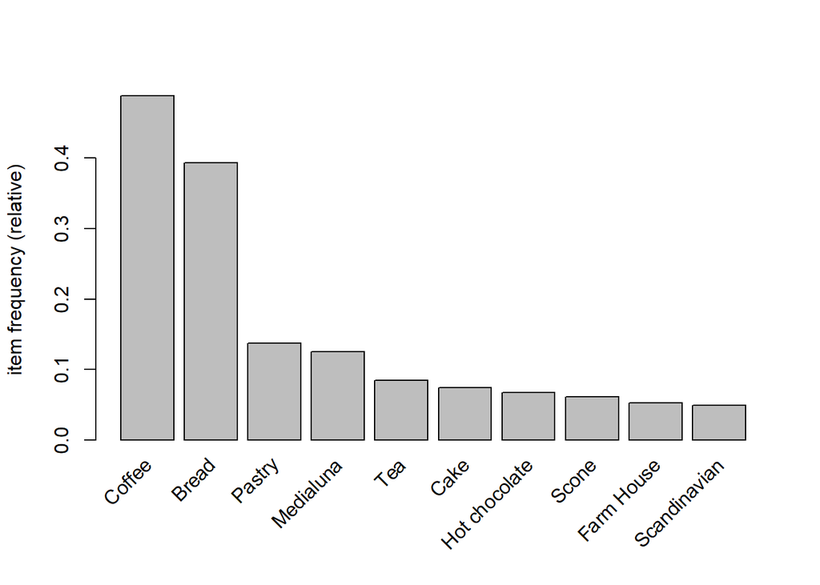

```r
itemFrequencyPlot(bread_weekend_morning_tr_df, topN = 10)
```

```r
rules_weekend_morning <- apriori(bread_weekend_morning_tr_df, parameter = list(supp = 0.005,
                                                                               conf = 0.8, minlen = 2))
```

```
## Apriori
##
## Parameter specification:
##  confidence minval smax arem  aval originalSupport maxtime support minlen
##         0.8    0.1    1 none FALSE            TRUE       5   0.005      2
##  maxlen target  ext
##      10  rules TRUE
##
## Algorithmic control:
##  filter tree heap memopt load sort verbose
##     0.1 TRUE TRUE  FALSE TRUE    2    TRUE
##
## Absolute minimum support count: 7
##
## set item appearances ...[0 item(s)] done [0.00s].
## set transactions ...[1523 item(s), 1456 transaction(s)] done [0.00s].
## sorting and recoding items ... [34 item(s)] done [0.00s].
## creating transaction tree ... done [0.00s].
## checking subsets of size 1 2 3 4 done [0.00s].
## writing ... [5 rule(s)] done [0.00s].
## creating S4 object  ... done [0.00s].
```

```r
rules_weekend_morning <- sort(rules_weekend_morning, by="confidence", decreasing = TRUE)
rules_weekend_morning
```

```
## set of 5 rules
```

```r
inspect(rules_weekend_morning)
```

```
##     lhs                   rhs      support     confidence coverage    lift
## [1] {The Nomad}        => {Coffee} 0.010302198 0.9375000  0.010989011 1.919831
## [2] {Keeping It Local} => {Coffee} 0.006868132 0.9090909  0.007554945 1.861655
## [3] {Smoothies}        => {Coffee} 0.006868132 0.9090909  0.007554945 1.861655
## [4] {Cake,Medialuna}   => {Coffee} 0.005494505 0.8888889  0.006181319 1.820284
## [5] {Spanish Brunch}   => {Coffee} 0.019917582 0.8529412  0.023351648 1.746670
##     count
## [1] 15
## [2] 10
## [3] 10
## [4]  8
## [5] 29
```

```
## To reduce overplotting, jitter is added! Use jitter = 0 to prevent jitter.
```

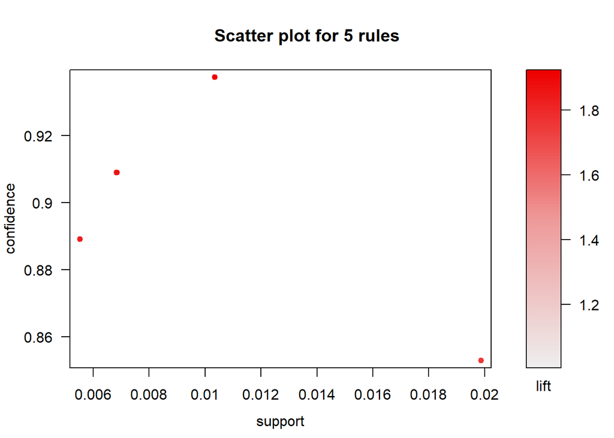

```r
plot(rules_weekend_morning)
```

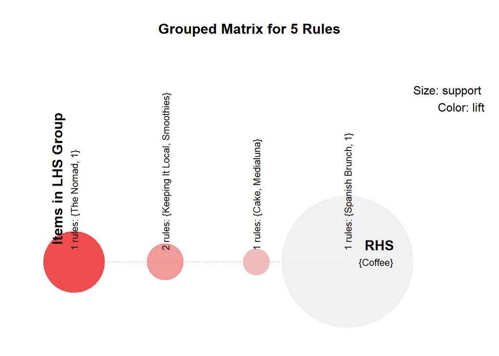

```r
plot(rules_weekend_morning,method = "grouped")
```

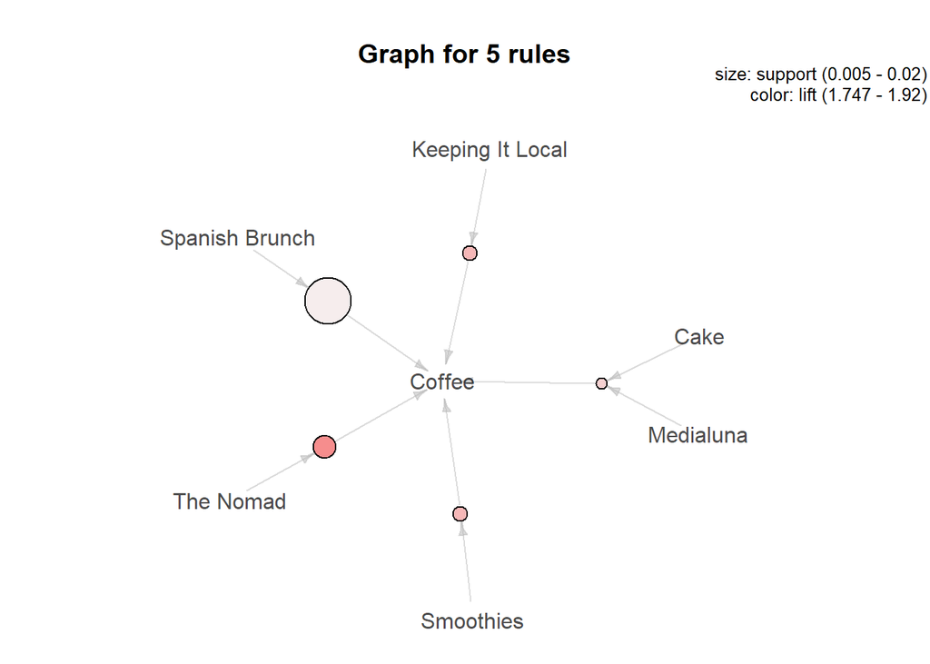

```r
plot(rules_weekend_morning,method = "graph")
```

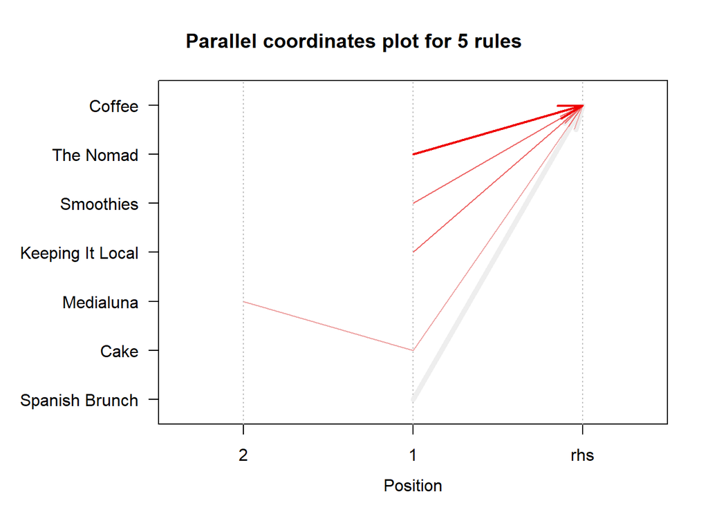

```r
plot(rules_weekend_morning,method = "paracoord")
```

As we can see, there are 5 rules and coffee still is the best selling product at the cafe, followed by bread and pastry in the weekend morning transactions. Through those rules, we can find out what products are bought along with coffee And it turns out they used to buy coffee with Spanish Brunch and The Nomad.

#### 4.3.2 Weekend Afternoon

In weekend afternoon, we set min. Support in 0.004 and min. Confident in 0.7

```r
bread_weekend_afternoon_df <- bread_weekend_df %>%
  filter(period_day=="afternoon")

str(bread_weekend_afternoon_df)
```

```
## tibble [4,296 x 6] (S3: tbl_df/tbl/data.frame)
##  $ Transaction    : num [1:4296] 43 43 44 44 45 45 45 46 47 47 ...
##  $ Item           : Factor w/ 94 levels "Adjustment","Afternoon with the baker",..: 75 41 24 56 24 49 56 24 34 52 ...
##  $ date_time      : chr [1:4296] "30-10-2016 12:00" "30-10-2016 12:00" "30-10-2016 12:05" "30-10-2016 12:05" ...
##  $ period_day     : chr [1:4296] "afternoon" "afternoon" "afternoon" "afternoon" ...
##  $ weekday_weekend: chr [1:4296] "weekend" "weekend" "weekend" "weekend" ...
##  $ Date           : Date[1:4296], format: "0030-10-20" "0030-10-20" ...
```

```r
head(bread_weekend_afternoon_df)
```

```
## # A tibble: 6 x 6
##   Transaction Item         date_time       period_day weekday_weekend Date
##         <dbl> <fct>        <chr>           <chr>      <chr>           <date>
## 1          43 Scandinavian 30-10-2016 12:~ afternoon  weekend         0030-10-20
## 2          43 Fudge        30-10-2016 12:~ afternoon  weekend         0030-10-20
## 3          44 Coffee       30-10-2016 12:~ afternoon  weekend         0030-10-20
## 4          44 Medialuna    30-10-2016 12:~ afternoon  weekend         0030-10-20
## 5          45 Coffee       30-10-2016 12:~ afternoon  weekend         0030-10-20
## 6          45 Hot chocola~ 30-10-2016 12:~ afternoon  weekend         0030-10-20
```

```r
summary(bread_weekend_afternoon_df)
```

```
##   Transaction              Item       date_time          period_day
##  Min.   :  43   Coffee       :1025   Length:4296        Length:4296
##  1st Qu.:2619   Bread        : 601   Class :character   Class :character
##  Median :5543   Tea          : 322   Mode  :character   Mode  :character
##  Mean   :5215   Cake         : 294
##  3rd Qu.:7577   Sandwich     : 229
##  Max.   :9684   Hot chocolate: 138
##                 (Other)      :1687
##  weekday_weekend         Date
##  Length:4296        Min.   :0001-04-20
##  Class :character   1st Qu.:0007-01-20
##  Mode  :character   Median :0014-01-20
##                     Mean   :0015-04-10
##                     3rd Qu.:0022-01-20
##                     Max.   :0031-12-20
##
```

```r
itemlist_weekend_afternoon <- ddply(bread_weekend_afternoon_df, c("Transaction"),
                                  function(df1)paste(df1$Item, collapse = ","))

itemlist_weekend_afternoon$Transaction <- NULL
colnames(itemlist_weekend_afternoon) <- c("items")

# Write to csv file
write.csv(itemlist_weekend_afternoon, "data/bread basket weekend afternoon.csv",
          quote = FALSE,
          row.names = TRUE)

# IMPORT AS TRANSACTION
bread_weekend_afternoon_tr_df <- read.transactions("data/bread basket weekend afternoon.csv",
                                                 format = "basket",
                                                 sep = ",")

bread_weekend_afternoon_tr_df
```

```
## transactions in sparse format with
##  1765 transactions (rows) and
##  1841 items (columns)
```

```r
summary(bread_weekend_afternoon_tr_df)
```

```
## transactions as itemMatrix in sparse format with
##  1765 rows (elements/itemsets/transactions) and
##  1841 columns (items) and a density of 0.001756035
##
## most frequent items:
##   Coffee    Bread      Tea     Cake Sandwich  (Other)
##      817      563      302      279      191     3554
##
## element (itemset/transaction) length distribution:
## sizes
##   1   2   3   4   5   6   7   8   9  10
##   1 645 501 331 176  81  22   5   2   1
##
##    Min. 1st Qu.  Median    Mean 3rd Qu.    Max.
##   1.000   2.000   3.000   3.233   4.000  10.000
##
## includes extended item information - examples:
##   labels
## 1      1
## 2     10
## 3    100
```

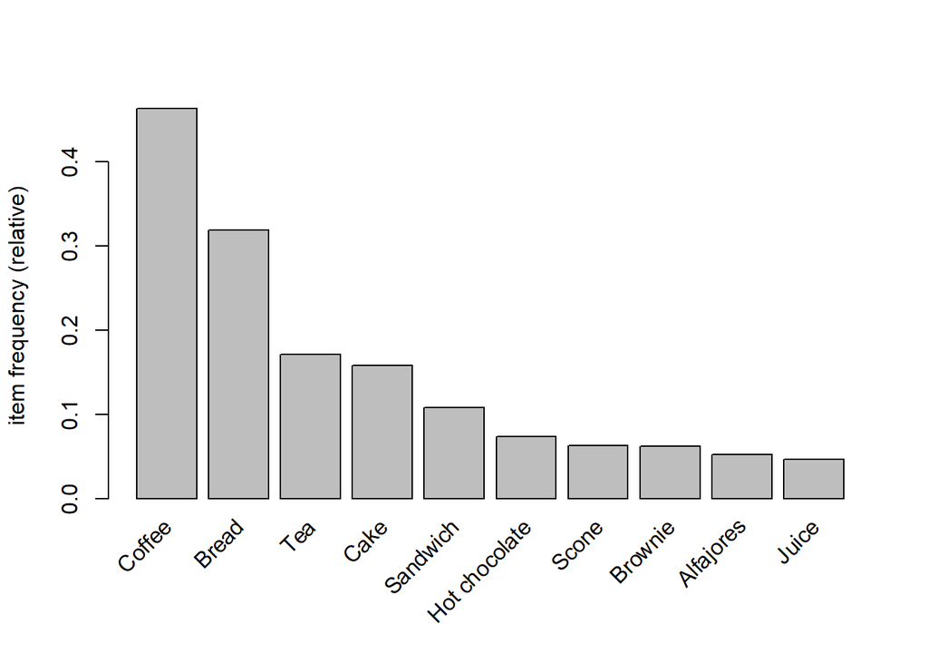

```r
itemFrequencyPlot(bread_weekend_afternoon_tr_df, topN = 10)
```

```r
rules_weekend_afternoon <- apriori(bread_weekend_afternoon_tr_df, parameter = list(supp = 0.004,
                                                                               conf = 0.7, minlen = 2))
```

```
## Apriori
##
## Parameter specification:
##  confidence minval smax arem  aval originalSupport maxtime support minlen
##         0.7    0.1    1 none FALSE            TRUE       5   0.004      2
##  maxlen target  ext
##      10  rules TRUE
##
## Algorithmic control:
##  filter tree heap memopt load sort verbose
##     0.1 TRUE TRUE  FALSE TRUE    2    TRUE
##
## Absolute minimum support count: 7
##
## set item appearances ...[0 item(s)] done [0.00s].
## set transactions ...[1841 item(s), 1765 transaction(s)] done [0.00s].
## sorting and recoding items ... [41 item(s)] done [0.00s].
## creating transaction tree ... done [0.00s].
## checking subsets of size 1 2 3 4 done [0.00s].
## writing ... [6 rule(s)] done [0.00s].
## creating S4 object  ... done [0.00s].
```

```r
rules_weekend_afternoon <- sort(rules_weekend_afternoon, by="confidence", decreasing = TRUE)
rules_weekend_afternoon
```

```
## set of 6 rules
```

```r
inspect(rules_weekend_afternoon)
```

```
##     lhs                        rhs      support     confidence coverage
## [1] {Juice,Toast}           => {Coffee} 0.004532578 1.0000000  0.004532578
## [2] {Art Tray}              => {Coffee} 0.004532578 0.8888889  0.005099150
## [3] {Sandwich,Soup}         => {Coffee} 0.005665722 0.7692308  0.007365439
## [4] {Hot chocolate,Scone}   => {Coffee} 0.005099150 0.7500000  0.006798867
## [5] {Cake,Tiffin}           => {Coffee} 0.004532578 0.7272727  0.006232295
## [6] {Cookies,Hot chocolate} => {Coffee} 0.004532578 0.7272727  0.006232295
##     lift     count
## [1] 2.160343  8
## [2] 1.920305  8
## [3] 1.661802 10
## [4] 1.620257  9
## [5] 1.571158  8
## [6] 1.571158  8
```

```
## To reduce overplotting, jitter is added! Use jitter = 0 to prevent jitter.
```

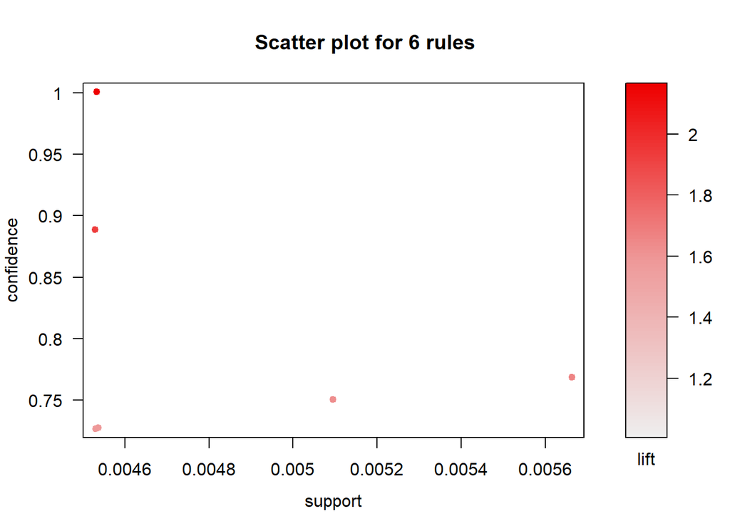

```r
plot(rules_weekend_afternoon)
```

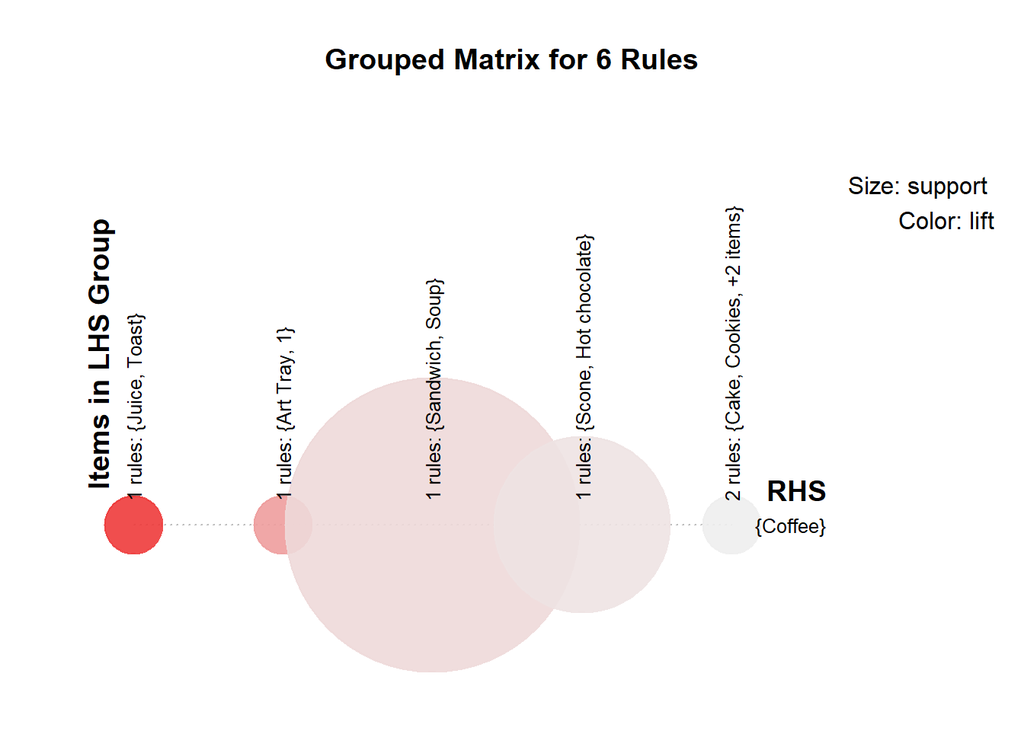

```r
plot(rules_weekend_afternoon,method = "grouped")
```

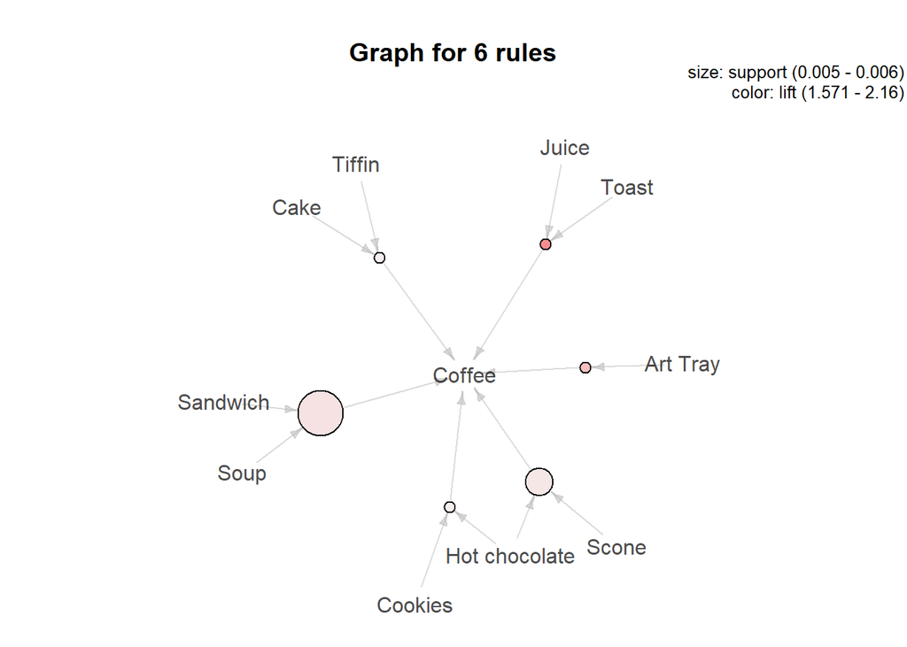

```r
plot(rules_weekend_afternoon,method = "graph")
```

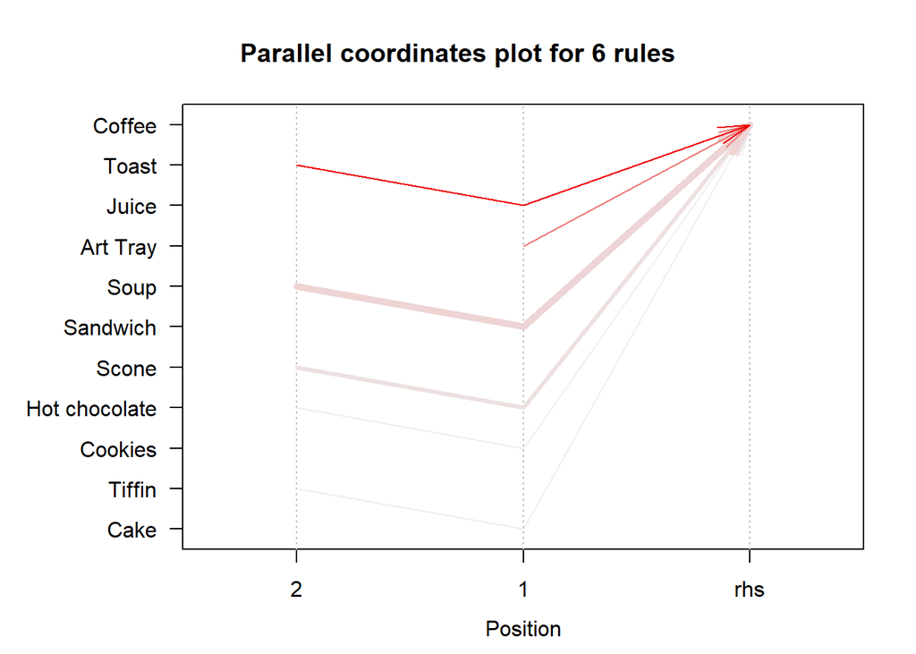

```r
plot(rules_weekend_afternoon,method = "paracoord")
```

As we can see, there are 6 rules and coffee still is the best selling product at the cafe, followed by bread and tea in the weekend afternoon transactions. Through those rules, we can find out what products are bought along with coffee And it turns out they used to buy coffee with Sandwich or Soup and Hot chocolate or Scone.

#### 4.3.2 Weekend Evening

```r
bread_weekend_evening_df <- bread_weekend_df %>%
  filter(period_day=="evening")

str(bread_weekend_evening_df)
```

```
## tibble [164 x 6] (S3: tbl_df/tbl/data.frame)
##  $ Transaction    : num [1:164] 647 647 737 738 738 ...
##  $ Item           : Factor w/ 94 levels "Adjustment","Afternoon with the baker",..: 56 66 3 66 32 5 83 41 62 54 ...
##  $ date_time      : chr [1:164] "05-11-2016 18:45" "05-11-2016 18:45" "06-11-2016 17:15" "06-11-2016 17:19" ...
##  $ period_day     : chr [1:164] "evening" "evening" "evening" "evening" ...
##  $ weekday_weekend: chr [1:164] "weekend" "weekend" "weekend" "weekend" ...
##  $ Date           : Date[1:164], format: "0005-11-20" "0005-11-20" ...
```

```r
head(bread_weekend_evening_df)
```

```
## # A tibble: 6 x 6
##   Transaction Item          date_time      period_day weekday_weekend Date
##         <dbl> <fct>         <chr>          <chr>      <chr>           <date>
## 1         647 Medialuna     05-11-2016 18~ evening    weekend         0005-11-20
## 2         647 Pastry        05-11-2016 18~ evening    weekend         0005-11-20
## 3         737 Alfajores     06-11-2016 17~ evening    weekend         0006-11-20
## 4         738 Pastry        06-11-2016 17~ evening    weekend         0006-11-20
## 5         738 Dulce de Lec~ 06-11-2016 17~ evening    weekend         0006-11-20
## 6        1273 Art Tray      13-11-2016 17~ evening    weekend         0013-11-20
```

```r
summary(bread_weekend_evening_df)
```

```
##   Transaction                         Item     date_time
##  Min.   : 647   Coffee                  :21   Length:164
##  1st Qu.:5993   Tshirt                  :21   Class :character
##  Median :6018   Afternoon with the baker:15   Mode  :character
##  Mean   :6119   Postcard                :10
##  3rd Qu.:7663   Bread                   : 9
##  Max.   :9231   Tea                     : 9
##                 (Other)                 :79
##   period_day        weekday_weekend         Date
##  Length:164         Length:164         Min.   :0001-04-20
##  Class :character   Class :character   1st Qu.:0004-02-20
##  Mode  :character   Mode  :character   Median :0005-03-20
##                                        Mean   :0009-05-25
##                                        3rd Qu.:0012-07-28
##                                        Max.   :0031-12-20
##
```

```r
itemlist_weekend_evening <- ddply(bread_weekend_evening_df, c("Transaction"),
                                  function(df1)paste(df1$Item, collapse = ","))

itemlist_weekend_evening$Transaction <- NULL
colnames(itemlist_weekend_evening) <- c("items")

# Write to csv file
write.csv(itemlist_weekend_evening, "data/bread basket weekend evening.csv",
          quote = FALSE,
          row.names = TRUE)

# IMPORT AS TRANSACTION
bread_weekend_evening_tr_df <- read.transactions("data/bread basket weekend evening.csv",
                                                 format = "basket",
                                                 sep = ",")

bread_weekend_evening_tr_df
```

```
## transactions in sparse format with
##  93 transactions (rows) and
##  135 items (columns)
```

```r
summary(bread_weekend_evening_tr_df)
```

```
## transactions as itemMatrix in sparse format with
##  93 rows (elements/itemsets/transactions) and
##  135 columns (items) and a density of 0.01943449
##
## most frequent items:
##                   Tshirt                   Coffee Afternoon with the baker
##                       19                       16                       14
##                 Postcard                    Bread                  (Other)
##                        9                        8                      178
##
## element (itemset/transaction) length distribution:
## sizes
##  1  2  3  4  5  6
##  1 57 21  6  6  2
##
##    Min. 1st Qu.  Median    Mean 3rd Qu.    Max.
##   1.000   2.000   2.000   2.624   3.000   6.000
##
## includes extended item information - examples:
##   labels
## 1      1
## 2     10
## 3     11
```

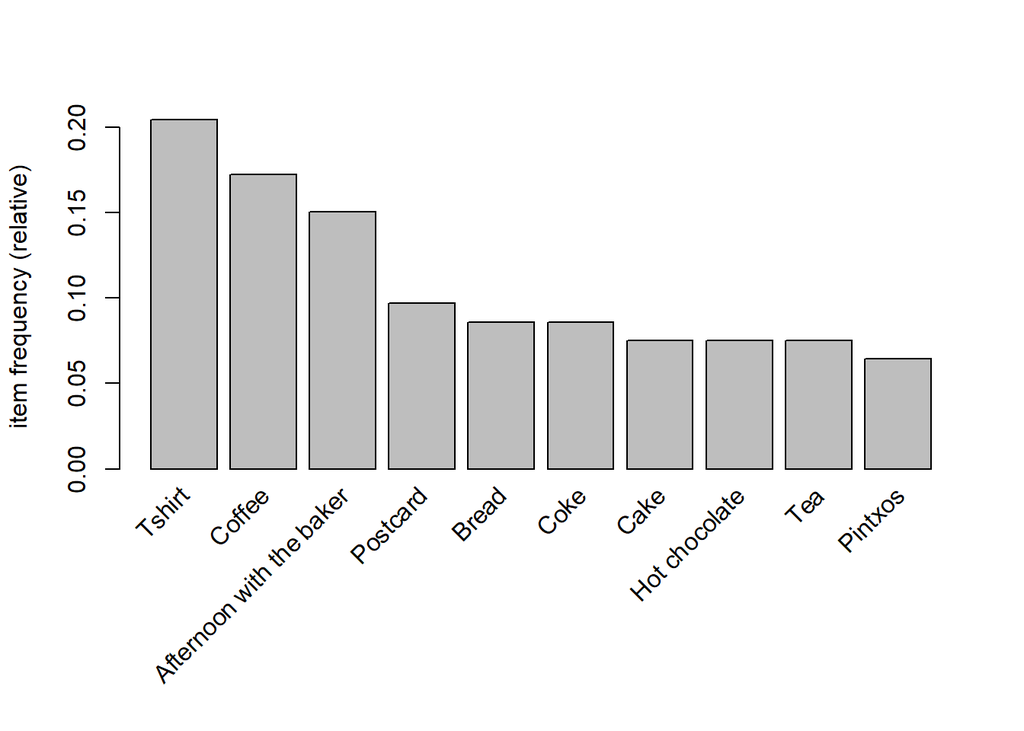

```r
itemFrequencyPlot(bread_weekend_evening_tr_df, topN = 10)
```

```r
rules_weekend_evening <- apriori(bread_weekend_evening_tr_df, parameter = list(supp = 0.02,
                                                                               conf = 0.9, minlen = 2))
```

```
## Apriori
##
## Parameter specification:
##  confidence minval smax arem  aval originalSupport maxtime support minlen
##         0.9    0.1    1 none FALSE            TRUE       5    0.02      2
##  maxlen target  ext
##      10  rules TRUE
##
## Algorithmic control:
##  filter tree heap memopt load sort verbose
##     0.1 TRUE TRUE  FALSE TRUE    2    TRUE
##
## Absolute minimum support count: 1
##
## set item appearances ...[0 item(s)] done [0.00s].
## set transactions ...[135 item(s), 93 transaction(s)] done [0.00s].
## sorting and recoding items ... [20 item(s)] done [0.00s].
## creating transaction tree ... done [0.00s].
## checking subsets of size 1 2 3 done [0.00s].
## writing ... [4 rule(s)] done [0.00s].
## creating S4 object  ... done [0.00s].
```

```r
rules_weekend_evening <- sort(rules_weekend_evening, by="confidence", decreasing = TRUE)
rules_weekend_evening
```

```
## set of 4 rules
```

```r
inspect(rules_weekend_evening)
```

```
##     lhs                   rhs      support    confidence coverage   lift
## [1] {Scone}            => {Coffee} 0.02150538 1          0.02150538  5.81250
## [2] {Medialuna,Tea}    => {Coffee} 0.02150538 1          0.02150538  5.81250
## [3] {Coffee,Medialuna} => {Tea}    0.02150538 1          0.02150538 13.28571
## [4] {Bread,Cake}       => {Coffee} 0.02150538 1          0.02150538  5.81250
##     count
## [1] 2
## [2] 2
## [3] 2
## [4] 2
```

```
## To reduce overplotting, jitter is added! Use jitter = 0 to prevent jitter.
```

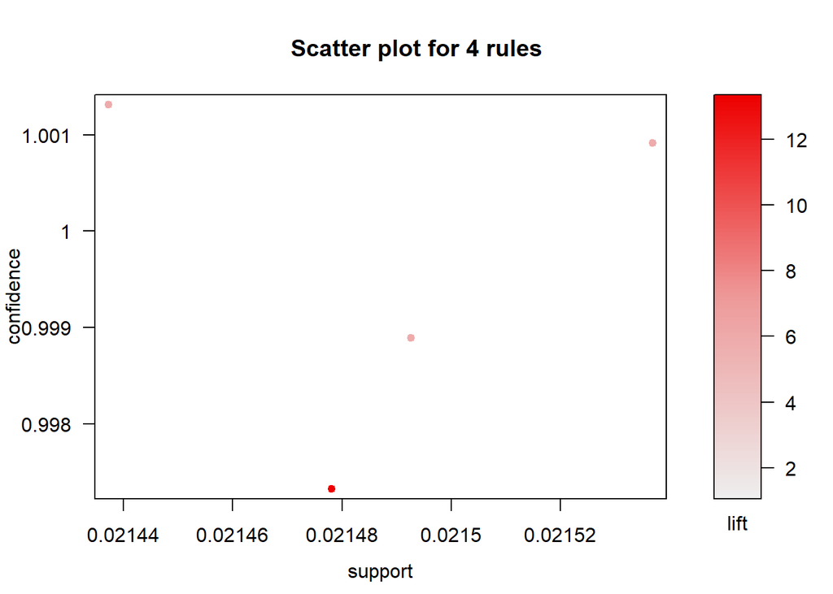

```r
plot(rules_weekend_evening)
```

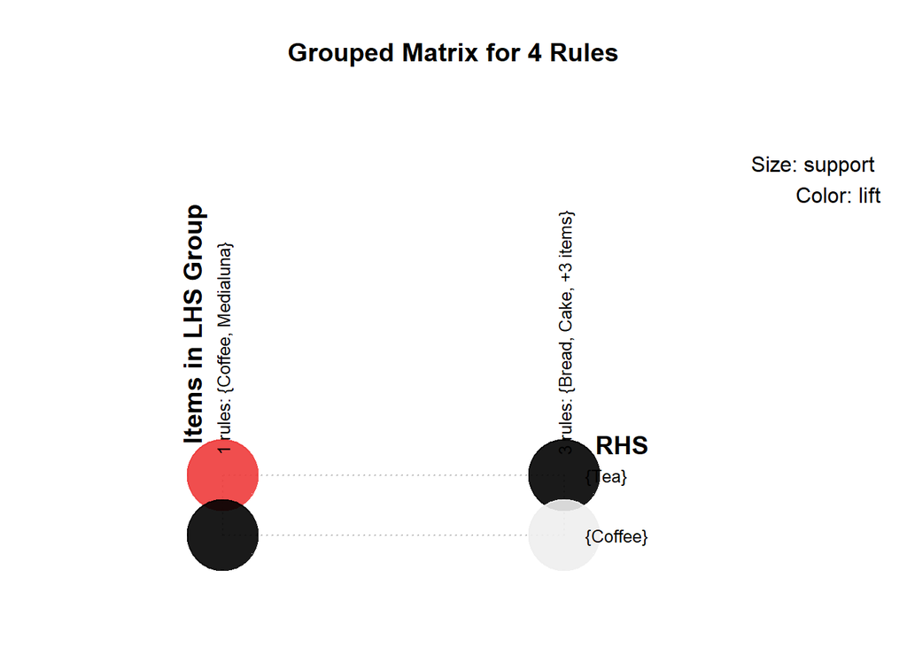

```r
plot(rules_weekend_evening,method = "grouped")
```

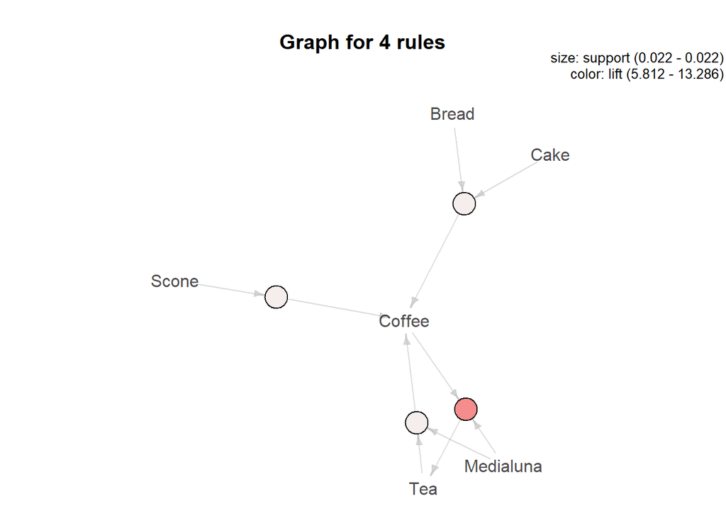

```r
plot(rules_weekend_evening,method = "graph")
```

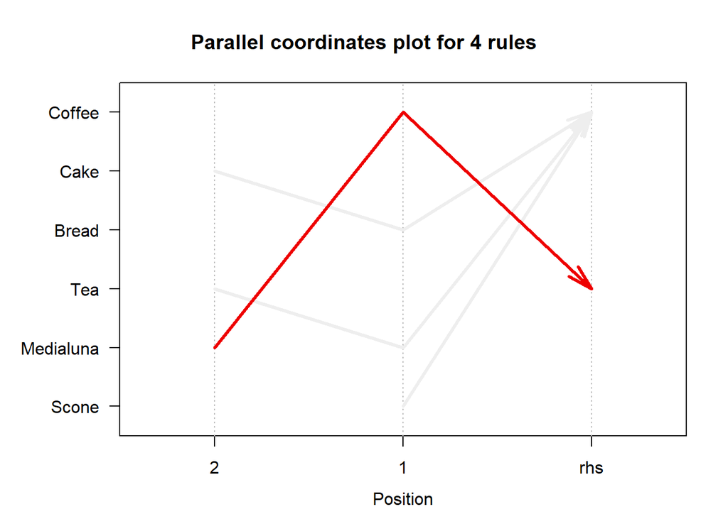

```r
plot(rules_weekend_evening,method = "paracoord")
```

## 4. Recommendations

1. Make a product package like Coffee + Bread in weekday or weekend morning, because in the morning mostly consumers wanted to buy coffee and bread.
2. Make a product package like Tea + Bread in weekday or weekday evening, because in the evening mostly consumers wanted to buy tea and bread besides coffee.
3. Launch a new food product in the weekday/weekend Afternoon.
4. Launch a new drink product in the weekday/weekend Morning.
5. Launch a new Marchandise in the weekend Evening.